# Identifying rewired proteins in comparative CF-MS data

–

This vignette demonstrates the application of the PrInCE function `calculate_autocorrelation` to identify rewired proteins in CF-MS data acquired from human cell lines before and after treatment with RNAse. This data is obtained from Mallam et al., *Cell Reports* 2019, doi: 10.1016/j.celrep.2019.09.060. To validate the biological relevance of these rewired proteins, a gene-set enrichment analysis is performed for known RNA-binding proteins from two databases: AtTRACT (Giudice et al., *Database* 2016; doi: 10.1093/database/baw035) and RBPDB (Cook et al., *Nucleic Acids Research* 2011; doi: 10.1093/nar/gkq1069).

First, we will load the data from Mallam et al. Data from human cell lines was obtained from the PRIDE repository (accession PXD014820 and PXD015406) and re-analyzed using MaxQuant (version 1.6.5.0, with default settings, using MaxLFQ for label-free protein quantitation). The MaxQuant output (`proteinGroups.txt` files) was then pre-processed using the script in `R/preprocessing/preprocess-Mallam2019.R`.

```r
chroms = readRDS("data/Mallam2019/chromatograms.rds")
names(chroms)
```

```
## [1] "PXD014820|Ctrl"    "PXD014820|RNAseA"  "PXD015406|Control"
## [4] "PXD015406|RNaseA"
```

Now, it is straightforward to calculate the autocorrelation for each protein between each pair of conditions. This function performs the following operations. First, for each individual protein in turn, the Pearson correlation to all other proteins in the dataset is calculated in each condition separately, yielding two vectors of correlation coefficients. These two vectors are then correlated to one another to produce an ‘autocorrelation.’ Low autocorrelation values are indicative of proteins whose interaction profiles are rewired between conditions, whereas high autocorrelation values indicate consistent elution profiles.

```r
# PXD014820
autocor1 = calculate_autocorrelation(chroms[['PXD014820|Ctrl']],
                                     chroms[['PXD014820|RNAseA']])
# PXD015406
autocor2 = calculate_autocorrelation(chroms[['PXD015406|Control']],
                                     chroms[['PXD015406|RNaseA']])
# inspect the output
str(autocor1)
```

```
##  Named num [1:4481] 0.76 0.628 0.824 0.387 0.783 ...
##  - attr(*, "names")= chr [1:4481] "HDGFRP3" "DNPEP" "HDLBP" "RPS9" ...
```

By default, the `calculate_autocorrelation` function will compute the Pearson correlation, but the Spearman or Kendall correlation can be specified instead using the `cor_method` argument. Other arguments to `calculate_autocorrelation` allow the user to remove proteins not detected in at least a certain number of fractions in either replicate (`min_fractions`), or to ignore correlations between protein pairs not detected in at least a certain number of overlapping fractions (`min_pairs`).

Now, we combine the results from each experiment and print some of the most ‘rewired’ proteins.

```r
autocor_df = data.frame(accession = rep(c('PXD014820', 'PXD015406'),
                                        c(length(autocor1), length(autocor2))),
                        protein = c(names(autocor1), names(autocor2)),
                        autocor = c(autocor1, autocor2) %>% unname())
autocor_df %>% arrange(autocor) %>% head()
```

```
##   accession protein    autocor
## 1 PXD014820   SRP14 -0.6616986
## 2 PXD014820  SNRPA1 -0.5764608
## 3 PXD014820 SYNCRIP -0.4688093
## 4 PXD014820   SNRPN -0.4655844
## 5 PXD014820   SNRPB -0.4655844
## 6 PXD014820   U2AF1 -0.4624829
```

Several of the top-ranking proteins, such as SRP14, SNRPA1, and SNRPN, are well-known RNA-binding proteins, providing an initial measure of confidence in the autocorrelation approach.

To validate the method’s ability to identify RNA-binding proteins more systematically, we now wish to perform a gene-set enrichment analysis of known RNA-binding proteins on the results of the autocorrelation analysis. To achieve this, we begin by loading lists of known human RNA-binding proteins from the AtTRACT and RNABP databases. (The raw datasets are preprocessed in the scripts `R/preprocessing/preprocess-AtTRACT.R` and `R/preprocessing/preprocess-RNABP.R`, respectively.)

```r
attract = readRDS("data/AtTRACT/AtTRACT.rds")
rbpdb = readRDS("data/RBPDB/RBPDB.rds")
rbps = bind_rows(mutate(attract, source = 'AtTRACT'),
                 mutate(rbpdb, source = 'RBPDB'))
sample_n(rbps, 5)
```

```
##        Species    Gene  source
## 1 Homo_sapiens   DDX58 AtTRACT
## 2 Homo sapiens   TAF15   RBPDB
## 3 Homo sapiens IGF2BP2   RBPDB
## 4 Homo_sapiens     SSB AtTRACT
## 5 Homo_sapiens    RBM6 AtTRACT
```

Here, the gene-set enrichment analysis is performed using functions from the package `fgsea` (Korotkevich et al., *bioRxiv* 2019, doi: 10.1101/060012).

```r
# convert RBPs to a list for fgsea
pathways = unstack(rbps[, c('Gene', 'source')])
str(pathways)
```

```
## List of 2
##  $ AtTRACT: chr [1:160] "A1CF" "ACO1" "ADAR" "AGO1" ...
##  $ RBPDB  : chr [1:405] "RBM6" "YBX2" "CSDE1" "PTBP1" ...
```

```r
gsea = autocor_df %>%
  split(.$accession) %>%
  # convert to vector for fgsea
  map(~ setNames(.x$autocor, .x$protein)) %>%
  # use only 10^5 permutations here
  map(~ fgsea(pathways, .x, nperm = 10^5, scoreType = 'neg')) %>%
  bind_rows(.id = 'accession')
gsea
```

```
##    accession pathway         pval         padj          ES        NES
## 1: PXD014820 AtTRACT 0.0006299937 0.0006299937 -0.11895136  -5.566628
## 2: PXD014820   RBPDB 0.0000099999 0.0000199998 -0.13193177 -10.400765
## 3: PXD015406 AtTRACT 0.0000399996 0.0000499995 -0.14571686  -8.714954
## 4: PXD015406   RBPDB 0.0000499995 0.0000499995 -0.08098069  -8.561360
##    nMoreExtreme size                                      leadingEdge
## 1:           62  101   SRP14,SYNCRIP,IGF2BP3,SNRPA,HNRNPU,IGF2BP1,...
## 2:            0  181     SYNCRIP,SNRPB,SNRPN,U2AF1,HNRNPR,IGF2BP3,...
## 3:            3  112 IGF2BP2,IGF2BP3,SNRPA,IGF2BP1,SYNCRIP,SNRPB2,...
## 4:            4  207   IGF2BP2,IGF2BP3,SNRPA,LARP7,LIN28B,IGF2BP1,...
```

Both RBP databases display a highly significant enrichment among ‘rewired’ proteins. This can also be visualized by plotting the -log p-values:

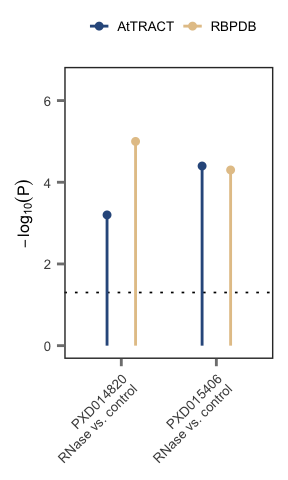

```r
pos = position_dodge(width = 0.6)
pal = c(colours.cafe322[5], darken(colours.cafe322[3], 1.1))
p = gsea %>%
  mutate(source = paste0(accession, '\nRNase vs. control')) %>%
  ggplot(aes(x = source, y = -log10(pval), color = pathway)) +
  geom_hline(aes(yintercept = -log10(0.05)), linetype = 'dotted', size = 0.3) +
  geom_errorbar(aes(ymin = 0, ymax = -log10(pval)), width = 0, position = pos) +
  geom_point(size = 0.9, position = pos) +
  scale_y_continuous(expression(-log[10](P)), limits = c(0, 6.5)) +
  scale_color_manual(name = '', values = pal) +
  boxed_theme(size_sm = 5, size_lg = 6) +
  theme(axis.title.x = element_blank(),
        axis.text.x = element_text(angle = 45, hjust = 1))
p
```